# Statistical Inference Notes

Devon Terrell

Tuesday, December 02, 2014

## Lecture 2: Probability

### Rules of Probability

- Probability of nothing occurring is 0
- Probability of something occurring is 1
- Probability of a single class of event, P(A), is 0 < P(A) < 1
- Probability of the opposite of A, P(A’) = 1 - P(A)
- If A and B are disjoint classes of events, P(AuB) = P(A)+P(B)
- Given two events (not necessarily disjoint) P(AuB) = P(A) + P(B) - P(AnB)
- If event A implies B, then P(A) < P(B)

### Probability Mass and Density Functions

- A *Probability Mass Function (PMF)* is a function P on a discrete domain D such that:
  - $\forall x \in D, P(x) > 0$
  - $\forall x \in D, \sum x = 1$
- A *Probability Density Function (PDF)* is a function P on a continuous domain D such that:
  - $\forall x \in D, P(x) > 0$
  - $\int\limits_D x = 1$

#### Example

The following PDF gives the percentage of help-desk service phone calls answered in a day.

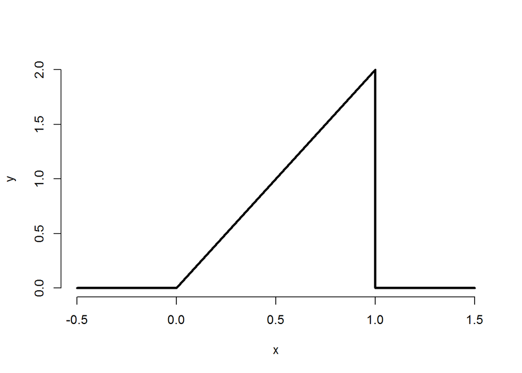

```r
x <- c(-0.5, 0, 1, 1, 1.5)
y <- c(0,0,2,0,0)
plot(x, y, lwd=3, frame=FALSE, type="l")
```

```r
f <- function(x){return(2*x)} # Eqn of the line
f(.75) * (.75 * .5) # 1/2 base times height
```

```
## [1] 0.5625
```

```r
# alternatively
pbeta(0.75, 2, 1)
```

```
## [1] 0.5625
```

### Cumulative Distribution Function (CDF)

- The *Cumulative Distribution Function* of a random variable, X, is the probability that the random variable is less than or equal to the value of x
  - $F(x)=P(X\le x)$
- The *Survival Function* iof a random variable, X, is the probability that the random variable is greater than the value of x
  - $F(x)=P(X\gt x)=1-P(X\le x)$

#### Example

What is the CDF and survival function from the density considered before?

```r
pbeta(c(0.4, 0.5, 0.6, 0.75), 2, 1) # pbeta is the CDF
```

```
## [1] 0.1600 0.2500 0.3600 0.5625
```

```r
1-pbeta(c(0.4, 0.5, 0.6, 0.75), 2, 1) # 1-pbeta is the survival function
```

```
## [1] 0.8400 0.7500 0.6400 0.4375
```

### Percentiles

- Given a PDF, the $\alpha^{th}$ percentile is the value x such that a randomly drawn value has $\alpha \%$ probability of being less than or equal to it.

### Example

What is the 50th percentile

$F(x)=P(X\le x)=\frac{1}{2} Base * Height=\frac{x}{2} * (2x) = x^2$ Solve $F(x)=x^2=0.5$

```r
sqrt(0.5)
```

```
## [1] 0.7071068
```

```r
# Alternatively
qbeta(0.5, 2, 1)
```

```
## [1] 0.7071068
```

### R Tricks

- `p` in front of a density function, as in `pbeta`, gives the *probability*
- `q` in front of a density function, as in `qbeta`, gives the *quantiles*

## Lecture 3: Conditional Probability

- Let $B$ be an event so that $P(B)>0$. Then the *conditional probability* of an even $A$ given that $B$ has occured is $P(A|B)=\frac{P(A\cap B)}{P(B)}$

### Bayes’ Rule

$P(B|A)=\frac{P(A|B)P(B)}{P(A|B)P(B)+P(A|B^c)P(B^c)}$

### Odds

The odds of a given even P occuring is $\frac{P}{1-P}$

#### Example

A fair die roll has a probability of $1/6$ of resulting in the number 1, and a probability of $5/6$ of [2,6]. So the odds are $\frac{1/6}{5/6}=\frac{1*6}{5*6}=1/5$, or $1:5$ odds.

### Independence

Two events A and B are independent if $P(A\cap B)=P(A)P(B)$ or alternatively if $P(A|B)=P(A)$

Intuitively, what this is saying is that if two events are independent, then the probability of both occurring is just the probability of each occuring individually. In the alternative definition, this is saying that the occurence of A given B is not influenced at all by B occurring.

#### Example

What is the probability of getting two consecutive heads on fair coin flips?

- $A = \mbox{Head on flip 1} \rightarrow P(A)=.5$
- $B = \mbox{Head on flip 2} \rightarrow P(B)=.5$
- $A\cap B = \mbox{Head on flips 1 and 2}$
- $P(A\cap B) = P(A)P(B) = .5 * .5 = .25$

## Lecture 4: Expectations

### Population Mean

- Intuitively, where would you put the pivot point to balance the distribution?
  - Applies for both continuous and discrete distributions
- Analytically $E(X) = \sum\limits_{x} x*p(x)$

### Sample Mean

The mean of infinitely many samples from a population is the same as the population itself.

### Average Mean

The mean of infinitely many averages of samples from a population is the same as the population, but the distribution of averages will be more focused on the mean.

## Lecture 5: Variance

The *variance* of a random variable is a measure of spread. Intuitively, it is a measure of how wide the distribution is.

### Variance Defined

If $X$ is a random variable with mean $\mu$ then the *variance of $X$* is defined as $Var(X)=E[(X-\mu)^2]=E[X^2] - E[X]^2$

- In otherwords, the variance is the expected squared distance from the mean
- Densities with higher variance are more spread out than those with lower
- The square root of the variance is called the **standard deviation**
- The standard deviation has the same units as $X$

#### Example

What is the variance of the result of a toss of a six sided die?

Recall, $E[X]=\sum\limits_{i=1}^{n} i*\frac{1}{n}$ for a fair die, and so for a six sided die, $E[x]=3.5$. Similarly, $E[X^2]=\sum\limits_{i=1}^{n} i^2 * \frac{1}{n}$ and so for a six sided die, $E[X^2]\approx 15.1666$. Therefore, $var(X)=E[X^2]-E[X^2]\approx 15.1666 - (3.5^2)\approx 2.92$

### Sample Variance

The average squared distance of the observations minus the sample mean.

$S^2=\frac{\sum\limits_{i-1} (X_i - X)^2}{n-1}$

### Standard Deviation

The standard deviation is the square root of the Sample Variance.

### Variance distribution of sample means

Recall that taking the average over multiple sample distributions of a probabilitiy yields a distribution that is centered at the *same* value, the mean, but that it gets *thinner* or more focused on the mean as more distributions are included in the average. This relationship can be formalized.

Let $\sigma$ be the variance of the original population. Then the variance of the average of $n$ such populations is $Var(X) = \sigma ^2 / n$. That is, as more samples are added, the variance approaches zero. This is called the standard error? I think?

### Summary

- The standard deviation, $S$ talks about how variable the population is
- The sample variance, $S^2$, estimates the population variance, $\sigma ^2$
- The distribution of the *sample variance* is centered around $\sigma ^2$
- As more values are included in the sample vairance, the distribution of the sample variances becomes more focused around $\sigma ^2$
- The variance of the sample mean is $\sigma ^2 /n$
  - It’s logical estimate is $s^2/n$
  - The logical estimate of the standard error is $\sqrt{s^2/n}=S/\sqrt{n}$
- The standard error, $S/\sqrt{n}$, talks about how variable averages of random samples of size $n$ from the population are.

### Summary

- The sample variance estimates the population variance
- The distribution of the sample variance is centered at what it’s estimating
- The distribution of the sample variance gets more concentrated around the population variance with larger sample sizes
- The variance of the sample mean is the population variance divided by $n$
  - The square root is the standard error
- We can say a lot about the distribution of averages from random samples, even though we only have one set of data.

## Cheat-Sheet

| Symbol | Name | Definition | R Func | Intuition |
| --- | --- | --- | --- | --- |
| $X$ | random variable | PDF/PMF, $P(x)$ | e.g. dnorm | A variable represented by a probability distribution |
| $x$ | sample | $x \in X$ | e.g. rnorm | A single occurance of a value drawn from a distribution |
| $cum(x)$ | cumulative prob | $F(x)=P(X \le x)$ | e.g. pnorm | The probability of being “at least” some result |
| $cum(x)'$ | quantile prob | $F(x)=P(X \gt x)$ | e.g. qnorm | The probability of being “greater than” some result |
| $\mu$ | population mean | $\sum\limits_{x \in X} x/n$ | ~ | The center of the distribution |
| $E[X]$ | expected value | $\sum \limits_{x} (x*p(x))$ | ~ | The sum of the value of each result times the likelihood of each result (integral in continuous space). Another term for the **population mean** |
| $\bar{X}$ | sample mean | $\sum\limits_{i=1}{n} x_i n$ | mean | The center of mass of the sample data. This is also known as the **arithmetic mean** or **average** |
| $Var(X)$ | Pop. Variance | $E[X^2] - (E[X])^2$ | ~ | How concentrated the distribution is around the **population mean**. “The mean of the square minus the square of the mean” |
| $S^2$ | Sample Variance | $S^2=\frac{\sum\limits_{i=1} (X_i - \bar{X})^2}{n-1}$ | var | How concentrated the sample data is around the **sample mean**. *Almost* the average squared distance from the sample mean. |
| $sd$, $\sigma$ | Pop Standard Deviation | $\sqrt{E[X^2] - (E[X])^2}$ | ~ | Same idea as the population variance, but in the same units as the population |
| $S$ | Sample Standard Deviation | $S=\sqrt{S^2}$ | sd | Same idea as the sample variance, but in the same units as the samples |

- The *sample mean* estimates the *population mean*, and so the distribution of sample means is centered around the population mean
- A collection of *sample means* from a *population* is itself a random variable (with an associated distribution) which has the same mean as the population itself
- The more samples that go into the sample mean, the more concentrated it is around the population mean
- The *sample variance* estimates the *population variance*, and so the distribution of sample variances is centered around the population variance
- The variance of sample means has a fixed relationship to the *standard deviation* and the number of samples, given by $Var(\bar{X})=\sigma ^2/n$, where $n$ is the number of observations in the sample. This is useful because we don’t have to repeat sample means to get its variance; we know the relationship
- The estimate of the variance of sample means is $S^2/n$
- The estimate of the standard error is $S/\sqrt{n}$
- The *standard deviation* relates to how variable the population is. The *standard error* relates to how variables average samples of size $n$ from the population are
- The *standard deviation* of a sampling distribution of a statistic is called the *standard error*